# Lab 02

```r
library(tidyverse)
library(GGally)
library(broom)
```

## Exercise 1

```r
Advertising <- read_delim("advertising.csv", delim = ",", na = ".")
```

```r
head(Advertising)
```

| TV | Radio | Newspaper | Sales |
| --- | --- | --- | --- |
| 230.1 | 37.8 | 69.2 | 22.1 |
| 44.5 | 39.3 | 45.1 | 10.4 |
| 17.2 | 45.9 | 69.3 | 12.0 |
| 151.5 | 41.3 | 58.5 | 16.5 |
| 180.8 | 10.8 | 58.4 | 17.9 |
| 8.7 | 48.9 | 75.0 | 7.2 |

```r
model_radio <- lm(Sales ~ Radio, data = Advertising)

# Summary of the model
summary(model_radio)
```

```
Call:
lm(formula = Sales ~ Radio, data = Advertising)

Residuals:
     Min       1Q   Median       3Q      Max
-15.5632  -3.5293   0.6714   4.2504   8.6796

Coefficients:
            Estimate Std. Error t value Pr(>|t|)
(Intercept)  12.2357     0.6535  18.724  < 2e-16 ***
Radio         0.1244     0.0237   5.251 3.88e-07 ***
---
Signif. codes:  0 ‘***’ 0.001 ‘**’ 0.01 ‘*’ 0.05 ‘.’ 0.1 ‘ ’ 1

Residual standard error: 4.963 on 198 degrees of freedom
Multiple R-squared:  0.1222,    Adjusted R-squared:  0.1178
F-statistic: 27.57 on 1 and 198 DF,  p-value: 3.883e-07
```

```r
tidy(model_radio)
```

| term | estimate | std.error | statistic | p.value |
| --- | --- | --- | --- | --- |
| (Intercept) | 12.2357220 | 0.65348629 | 18.72376 | 1.081986e-45 |
| Radio | 0.1244317 | 0.02369603 | 5.25116 | 3.882892e-07 |

```r
glance(model_radio)
```

| r.squared | adj.r.squared | sigma | statistic | p.value | df | logLik | AIC | BIC | deviance | df.residual | nobs |
| --- | --- | --- | --- | --- | --- | --- | --- | --- | --- | --- | --- |
| 0.1222419 | 0.1178088 | 4.962898 | 27.57468 | 3.882892e-07 | 1 | -603.1806 | 1212.361 | 1222.256 | 4876.81 | 198 | 200 |

```r
# Fit the linear model for Sales vs. TV
model_tv <- lm(Sales ~ TV, data = Advertising)

# Summary of the model
summary(model_tv)
```

```
Call:
lm(formula = Sales ~ TV, data = Advertising)

Residuals:
    Min      1Q  Median      3Q     Max
-6.4438 -1.4857  0.0218  1.5042  5.6932

Coefficients:
            Estimate Std. Error t value Pr(>|t|)
(Intercept) 6.974821   0.322553   21.62   <2e-16 ***
TV          0.055465   0.001896   29.26   <2e-16 ***
---
Signif. codes:  0 ‘***’ 0.001 ‘**’ 0.01 ‘*’ 0.05 ‘.’ 0.1 ‘ ’ 1

Residual standard error: 2.296 on 198 degrees of freedom
Multiple R-squared:  0.8122,    Adjusted R-squared:  0.8112
F-statistic: 856.2 on 1 and 198 DF,  p-value: < 2.2e-16
```

```r
tidy(model_tv)
```

| term | estimate | std.error | statistic | p.value |
| --- | --- | --- | --- | --- |
| (Intercept) | 6.97482149 | 0.322553485 | 21.62377 | 5.027719e-54 |
| TV | 0.05546477 | 0.001895551 | 29.26050 | 7.927912e-74 |

```r
glance(model_tv)
```

| r.squared | adj.r.squared | sigma | statistic | p.value | df | logLik | AIC | BIC | deviance | df.residual | nobs |
| --- | --- | --- | --- | --- | --- | --- | --- | --- | --- | --- | --- |
| 0.8121757 | 0.8112271 | 2.295746 | 856.1767 | 7.927912e-74 | 1 | -448.9942 | 903.9884 | 913.8834 | 1043.549 | 198 | 200 |

- Is any of the models (assuming we can trust statistical information given by the fitting procedure) useful for predictions? Why?

Yes, because the perform better than using constant value. They contain some information that on average allow us to provide better …

- Which one is better and why?

If we believe future behaves as past, adj.r.score is reasonable estimate how model should behave in the future (adj possibility of overfitting is taken into account). The larger value is better. 0 if model gives average and 1 if always correct.

TV model is more useful because it has 0.8112271

- What is the average increase of the number of units sold per additional thousand dollars spent on Radio advertising? Same question about TV advertising?

For Radio increase is ~124 For TV increase is ~55

How accurately we can predict the average number of units sold when 100000 dollars are spent on TV advertising? Give prediction and 80% confidence interval!

? what does it mean we can predict average behaviour but not the real prediction? If the average is what you’re after, if you really want to say what would be in the future?

```r
# Data for $100,000 spent on TV advertising
new_data <- data.frame(TV = 100)

# Predicting with confidence interval
prediction <- predict(model_tv, newdata = new_data, interval = "confidence", level = 0.80)
print(prediction)
```

```
      fit      lwr      upr
1 12.5213 12.28314 12.75945
```

How accurately we can predict the number of units sold when 100000 dollars are spent on TV advertising? Give prediction and 80% prediction interval!

```r
# Predicting with prediction interval
prediction_interval <- predict(model_tv, newdata = new_data, interval = "prediction", level = 0.80)
print(prediction_interval)
```

```
      fit      lwr      upr
1 12.5213 9.559741 15.48286
```

Use augmentcommand to add model performance information (fitted values, residuals, …) to the data which was used for fitting the model Sales~TV. Use this augmented data set to form a point plot of data (Sales vs TV) together with line plot of predictions (using color=“red” outside of aes() command)

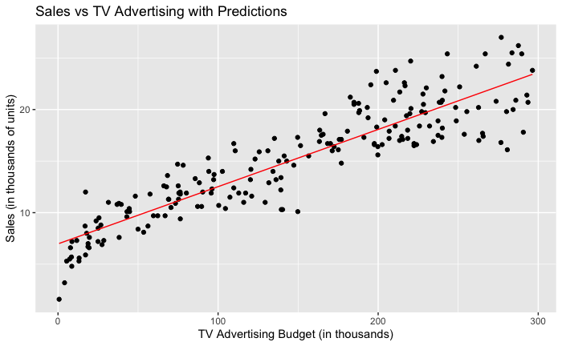

```r
# Augment the model with fitted values and residuals
augmented_data <- augment(model_tv, Advertising)

# Plot Sales vs TV with predictions (line in red)
ggplot(augmented_data, aes(x = TV, y = Sales)) +
  geom_point() +                              # Actual data points
  geom_line(aes(y = .fitted), color = "red") + # Fitted values
  labs(title = "Sales vs TV Advertising with Predictions",
       x = "TV Advertising Budget (in thousands)",
       y = "Sales (in thousands of units)")
```

Variability is not constant. Variance increases when budget increases. When constant variance is not sutisfied we can’t trust of prediction.

Fit a model for Sales using all predictors in the data set. Compare it to the model with the least important predictor removed. Does removing a predictor reduce or increase the quality of the model? Why?

```r
Sales_all = lm(Sales~., data=Advertising)
glance(Sales_all)
```

| r.squared | adj.r.squared | sigma | statistic | p.value | df | logLik | AIC | BIC | deviance | df.residual | nobs |
| --- | --- | --- | --- | --- | --- | --- | --- | --- | --- | --- | --- |
| 0.9025913 | 0.9011003 | 1.661695 | 605.3801 | 8.133735e-99 | 3 | -383.3351 | 776.6702 | 793.1618 | 541.2012 | 196 | 200 |

```r
tidy(Sales_all)
```

| term | estimate | std.error | statistic | p.value |
| --- | --- | --- | --- | --- |
| (Intercept) | 4.6251240788 | 0.307501165 | 15.04099695 | 1.682677e-34 |
| TV | 0.0544457803 | 0.001375188 | 39.59152448 | 1.892945e-95 |
| Radio | 0.1070012282 | 0.008489563 | 12.60385655 | 4.602097e-27 |
| Newspaper | 0.0003356579 | 0.005788056 | 0.05799148 | 9.538145e-01 |

```r
Sales_TV_Radio = lm(Sales~.-Newspaper, data=Advertising)
glance(Sales_TV_Radio)
```

| r.squared | adj.r.squared | sigma | statistic | p.value | df | logLik | AIC | BIC | deviance | df.residual | nobs |
| --- | --- | --- | --- | --- | --- | --- | --- | --- | --- | --- | --- |
| 0.9025896 | 0.9016007 | 1.657487 | 912.6859 | 2.385704e-100 | 2 | -383.3368 | 774.6736 | 787.8669 | 541.2105 | 197 | 200 |

```r
tidy(Sales_TV_Radio)
```

| term | estimate | std.error | statistic | p.value |
| --- | --- | --- | --- | --- |
| (Intercept) | 4.63087946 | 0.290308085 | 15.95160 | 2.526447e-37 |
| TV | 0.05444896 | 0.001370614 | 39.72598 | 5.427771e-96 |
| Radio | 0.10717457 | 0.007925809 | 13.52222 | 6.662856e-30 |

AIC and BIC is smaller should indicate better model. Removing variable probably gives us better model for describing variable. adj.r.squared increases

## Exercise 2

Use tidymodels framework to fit a linear model for Sales in terms of Radio for the advertising data set. Compute prediction in the case when 20000 dollars is spent on radio advertising together with 95% prediction interval and 95% confidence interval.

```r
library(tidymodels)
library(tidyverse)
```

```r
rec <- recipe(Sales ~ Radio, data = Advertising)
```

```r
model_spec <- linear_reg()
```

```r
wf <- workflow() |>
  add_model(model_spec) |>
  add_recipe(rec)
```

```r
fitted_workflow <- wf |> fit(data = Advertising)
```

```r
glance(fitted_workflow)
```

| r.squared | adj.r.squared | sigma | statistic | p.value | df | logLik | AIC | BIC | deviance | df.residual | nobs |
| --- | --- | --- | --- | --- | --- | --- | --- | --- | --- | --- | --- |
| 0.1222419 | 0.1178088 | 4.962898 | 27.57468 | 3.882892e-07 | 1 | -603.1806 | 1212.361 | 1222.256 | 4876.81 | 198 | 200 |

```r
tidy(fitted_workflow)
```

| term | estimate | std.error | statistic | p.value |
| --- | --- | --- | --- | --- |
| (Intercept) | 12.2357220 | 0.65348629 | 18.72376 | 1.081986e-45 |
| Radio | 0.1244317 | 0.02369603 | 5.25116 | 3.882892e-07 |

```r
augment(fitted_workflow, new_data=Advertising)
```

| .pred | .resid | TV | Radio | Newspaper | Sales |
| --- | --- | --- | --- | --- | --- |
| 16.93924 | 5.16076146 | 230.1 | 37.8 | 69.2 | 22.1 |
| 17.12589 | -6.72588603 | 44.5 | 39.3 | 45.1 | 10.4 |
| 17.94713 | -5.94713495 | 17.2 | 45.9 | 69.3 | 12.0 |
| 17.37475 | -0.87474934 | 151.5 | 41.3 | 58.5 | 16.5 |
| 13.57958 | 4.32041615 | 180.8 | 10.8 | 58.4 | 17.9 |
| 18.32043 | -11.12042992 | 8.7 | 48.9 | 75.0 | 7.2 |
| 16.31708 | -4.51708027 | 57.5 | 32.8 | 23.5 | 11.8 |
| 14.67458 | -1.47458241 | 120.2 | 19.6 | 11.6 | 13.2 |
| 12.49703 | -7.69702844 | 8.6 | 2.1 | 1.0 | 4.8 |
| 12.55924 | 3.04075573 | 199.8 | 2.6 | 21.2 | 15.6 |

[output cut: 190 more lines]

```r
new_data <- tibble(Radio = 20)
```

```r
# Prediction interval
prediction_interval <- predict(fitted_workflow, new_data, type = "pred_int", level = 0.95)

# Confidence interval
confidence_interval <- predict(fitted_workflow, new_data, type = "conf_int", level = 0.95)
```

[output not shown]

```r
linear_model_fit <- extract_fit_engine(fitted_workflow)

# Augment the data with fitted values and residuals
augmented_data <- augment(linear_model_fit, Advertising)
```

```r
augmented_data
```

| TV | Radio | Newspaper | Sales | .fitted | .hat | .sigma | .cooksd | .std.resid |
| --- | --- | --- | --- | --- | --- | --- | --- | --- |
| 230.1 | 37.8 | 69.2 | 22.1 | 16.93924 | 0.009816932 | 4.961738 | 5.413420e-03 | 1.04501066 |
| 44.5 | 39.3 | 45.1 | 10.4 | 17.12589 | 0.010862364 | 4.952093 | 1.019552e-02 | -1.36265471 |
| 17.2 | 45.9 | 69.3 | 12.0 | 17.94713 | 0.016681000 | 4.957096 | 1.238649e-02 | -1.20844047 |
| 151.5 | 41.3 | 58.5 | 16.5 | 17.37475 | 0.012415853 | 4.975083 | 1.977402e-04 | -0.17736227 |
| 180.8 | 10.8 | 58.4 | 17.9 | 13.57958 | 0.008541568 | 4.965865 | 3.292601e-03 | 0.87428496 |
| 8.7 | 48.9 | 75.0 | 7.2 | 18.32043 | 0.019982393 | 4.910687 | 5.223027e-02 | -2.26344174 |
| 57.5 | 32.8 | 23.5 | 11.8 | 16.31708 | 0.007073066 | 4.964984 | 2.971585e-03 | -0.91340597 |
| 120.2 | 19.6 | 11.6 | 13.2 | 14.67458 | 0.005306049 | 4.974363 | 2.367172e-04 | -0.29791268 |
| 8.6 | 2.1 | 1.0 | 4.8 | 12.49703 | 0.015211186 | 4.944694 | 1.886351e-02 | -1.56284612 |
| 199.8 | 2.6 | 21.2 | 15.6 | 12.55924 | 0.014734406 | 4.970688 | 2.848974e-03 | 0.61726202 |

[output cut: 190 more lines]

## Exercise 3

What does Augment do?

```r
baseplot = ggplot(augment(Sales_TV_Radio))
```

### Fitted values vs residuals (prediction errors).

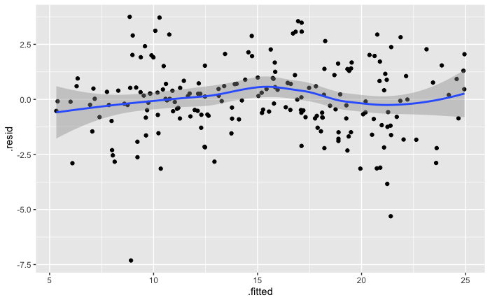

```r
baseplot + geom_point(aes(x=.fitted, y=.resid)) + geom_smooth(aes(x=.fitted, y=.resid))
```

*Bias* means that we may have mostly positive errors for some predicted values (for example, for small predicted values or for large values of a predictor) and mostly positive errors for some other region of predicted values or predictor values.

*Heteroscedasticity* means that the size of the residuals change with the predicted value. This also makes statistical information about coefficients invalid. Often can be corrected by using logarithmic (or more general Box-Cox) transformation of the response variable or by adding relevant variables to the model.

### Predictors vs residuals: TV

Help to detect prediction bias for some values of given predictor. Can be corrected by adding suitable computed variables.

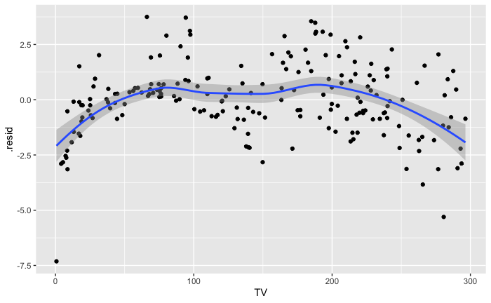

```r
baseplot + geom_point(aes(x=TV, y=.resid)) + geom_smooth(aes(x=TV, y=.resid))
```

There’s a bias in certain regions. Add polynomials is not the good choice.

### quantile-quantile plot

quantile-quantile plot with respect to normal distribution. Measures of fit which use likelihood of observations are computed under assumption of normal distribution and may be invalid when actual distribution of residuals is quite different from the normal distribution. Additionally important in the case of small data sets

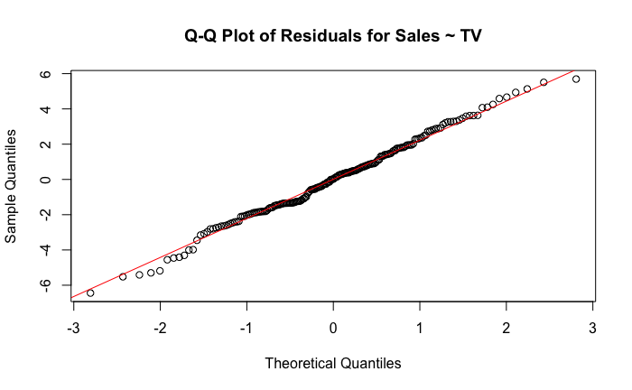

```r
residuals_tv <- resid(model_tv)

qqnorm(residuals_tv, main = "Q-Q Plot of Residuals for Sales ~ TV")
qqline(residuals_tv, col = "red")
```

### Plot of standardized residuals vs leverage

Residuals give information about outliers (suspicious values of the response variable). Leverage is a measure of how much a change in particular 𝑦value at given 𝐱influences predicted vale 𝑦̂ (depends only on how different the current 𝐱 is from the average 𝐱 value and on the number of observations). High leverage indicates data points which may potentially have large influence on the fitted model. Combination of large (in absolute value) residual and large leverage indicates a point which influences model quite strongly. Cook’s distance measures how much predictions change when a given point is removed from the data set and practical recommendation is that points with Cook’s distance higher than 1 should be very carefully checked.

[figure not shown]

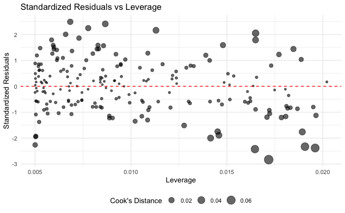

```r
# Load required package
library(ggplot2)

# Calculate leverage and standardized residuals
leverage <- hatvalues(model_tv)
standardized_residuals <- rstandard(model_tv)

# Cook's distance
cooks_distance <- cooks.distance(model_tv)

# Create a data frame to store leverage, residuals, and Cook's distance
influence_data <- data.frame(leverage, standardized_residuals, cooks_distance)

# Plot standardized residuals vs leverage with Cook's distance as size
ggplot(influence_data, aes(x = leverage, y = standardized_residuals)) +
  geom_point(aes(size = cooks_distance), alpha = 0.6) +
  geom_hline(yintercept = 0, color = "red", linetype = "dashed") +
  labs(title = "Standardized Residuals vs Leverage",
       x = "Leverage",
       y = "Standardized Residuals") +
  theme_minimal() +
  scale_size_continuous(name = "Cook's Distance") +
  theme(legend.position = "bottom")
```

```r
prefix <- "/Users/maksimploter/projects/ML/statistical-ml/labs/lab01/Datasets of Lab 1-20240905/"

auto_data <- read_delim(paste0(prefix, "Auto.csv"), delim = ",")
```

```r
model_weight = lm(mpg~weight, data=auto_data)
glance(model_weight)
```

| r.squared | adj.r.squared | sigma | statistic | p.value | df | logLik | AIC | BIC | deviance | df.residual | nobs |
| --- | --- | --- | --- | --- | --- | --- | --- | --- | --- | --- | --- |
| 0.6926304 | 0.6918423 | 4.332712 | 878.8309 | 6.015296e-102 | 1 | -1129.969 | 2265.939 | 2277.852 | 7321.234 | 390 | 392 |

```r
tidy(model_weight)
```

| term | estimate | std.error | statistic | p.value |
| --- | --- | --- | --- | --- |
| (Intercept) | 46.216524549 | 0.7986724633 | 57.86668 | 1.623069e-193 |
| weight | -0.007647343 | 0.0002579633 | -29.64508 | 6.015296e-102 |

```r
# Summary of the model
summary(model_weight)
```

```
Call:
lm(formula = mpg ~ weight, data = auto_data)

Residuals:
     Min       1Q   Median       3Q      Max
-11.9736  -2.7556  -0.3358   2.1379  16.5194

Coefficients:
             Estimate Std. Error t value Pr(>|t|)
(Intercept) 46.216524   0.798673   57.87   <2e-16 ***
weight      -0.007647   0.000258  -29.64   <2e-16 ***
---
Signif. codes:  0 ‘***’ 0.001 ‘**’ 0.01 ‘*’ 0.05 ‘.’ 0.1 ‘ ’ 1

Residual standard error: 4.333 on 390 degrees of freedom
Multiple R-squared:  0.6926,    Adjusted R-squared:  0.6918
F-statistic: 878.8 on 1 and 390 DF,  p-value: < 2.2e-16
```

p-value is small (commonly less than 0.05), the null hypothesis is rejected, indicating that the predictor variable is likely to have a statistically significant effect on the response variable.

[figure not shown]

[figure not shown]

[figure not shown]

[figure not shown]

```r
# Create a recipe: Add inv_weight (1/weight) and remove the original weight
rec <- recipe(mpg ~ weight, data = auto_data) |>
  step_mutate(inv_weight = 1/weight) |>  # Add inv_weight
  step_rm(weight)  # Remove the original weight variable


# Specify the model (linear regression)
model_spec <- linear_reg()

# Create a workflow to combine the recipe and model
wf <- workflow() %>%
  add_model(model_spec) %>%
  add_recipe(rec)

# Fit the model
fitted_wf <- wf %>% fit(data = auto_data)

# View the fitted model results
tidy(fitted_wf)
```

[output not shown]

```r
# Extract the fitted linear model
fitted_model <- extract_fit_engine(fitted_wf)

# Summary of the fitted model
summary(fitted_model)
```

[output not shown]

```r
par(mfrow = c(2, 2))  # Plot all diagnostics at once
plot(fitted_model)
```

[output not shown]

### Exercise 4

Let us use data set iris which is included in R default datasets. fit a linear model for Sepal.Length in terms of Petal.Length and the name of spieces

```r
model1 <- lm(Sepal.Length ~ Petal.Length + Species, data = iris)
summary(model1)
```

```
Call:
lm(formula = Sepal.Length ~ Petal.Length + Species, data = iris)

Residuals:
     Min       1Q   Median       3Q      Max
-0.75310 -0.23142 -0.00081  0.23085  1.03100

Coefficients:
                  Estimate Std. Error t value Pr(>|t|)
(Intercept)        3.68353    0.10610  34.719  < 2e-16 ***
Petal.Length       0.90456    0.06479  13.962  < 2e-16 ***
Speciesversicolor -1.60097    0.19347  -8.275 7.37e-14 ***
Speciesvirginica  -2.11767    0.27346  -7.744 1.48e-12 ***
---
Signif. codes:  0 ‘***’ 0.001 ‘**’ 0.01 ‘*’ 0.05 ‘.’ 0.1 ‘ ’ 1

Residual standard error: 0.338 on 146 degrees of freedom
Multiple R-squared:  0.8367,    Adjusted R-squared:  0.8334
F-statistic: 249.4 on 3 and 146 DF,  p-value: < 2.2e-16
```

```r
model2 <- lm(Sepal.Length ~ Petal.Length * Species, data = iris)
summary(model2)
```

```
Call:
lm(formula = Sepal.Length ~ Petal.Length * Species, data = iris)

Residuals:
     Min       1Q   Median       3Q      Max
-0.73479 -0.22785 -0.03132  0.24375  0.93608

Coefficients:
                               Estimate Std. Error t value Pr(>|t|)
(Intercept)                      4.2132     0.4074  10.341  < 2e-16 ***
Petal.Length                     0.5423     0.2768   1.959  0.05200 .
Speciesversicolor               -1.8056     0.5984  -3.017  0.00302 **
Speciesvirginica                -3.1535     0.6341  -4.973 1.85e-06 ***
Petal.Length:Speciesversicolor   0.2860     0.2951   0.969  0.33405
Petal.Length:Speciesvirginica    0.4534     0.2901   1.563  0.12029
---
Signif. codes:  0 ‘***’ 0.001 ‘**’ 0.01 ‘*’ 0.05 ‘.’ 0.1 ‘ ’ 1

Residual standard error: 0.3365 on 144 degrees of freedom
Multiple R-squared:  0.8405,    Adjusted R-squared:  0.8349
F-statistic: 151.7 on 5 and 144 DF,  p-value: < 2.2e-16
```

Compare the previous model to the model which contains also interactions of the two predictors used in the previous model. Which one would you use for predictions?

```r
# Load the iris dataset
data(iris)

# Split data into training and testing sets
set.seed(123)
iris_split <- initial_split(iris, prop = 0.8)
```

[output not shown]